# Legislative Update

Robert Kahne

2018-02-11

A few days ago, LRC director David Byerman tweeted that the LRC would supply voting information in both `csv` and `json` file formats. Since then, he has deleted that tweet, and the page which hosted the files has disappeared. While that is disappointing, take heart! I wrote a program which scrapes the LRC website for voting information using the `rOpenSci` package tabulizer. That, along with the great API provided by legiscan, allows the opportunity to do plenty of analysis over the 2018 Kentucky General Assembly.

As of February 9, the Kentucky legislature has completed 22 “legislative days.” In even numbered years, the legislature is required to pass a budget bill, and has 60 legislative days to complete that task. Governor Bevin guaranteed that the legislature would go into special session at some point in 2018 in order to pass a pension reform bill. This special session never occurred. There were several reasons floated as to *why* – perhaps the most compelling reason being that the Speaker of the House was embroiled in a sexual harassment scandal when it was revealed that he settled a claim with a woman who was on his staff. Regardless, Kentuckians expected the 2018 to be a very full session, with major issues like the budget and pension reform on the docket, and many clamoring for reform to the tax system in the state.

Despite the many issues the legislature faced, neither chamber has been very busy, and neither chamber is taking very many tough votes. Four bills have made it through the legislature so far. In the first 5 legislative days of the 2017 session, the legislature passed seven bills (this was highly unusual, but the point remains). In Kentucky, the filing deadline to run for office is January 30. Many tenured observers of the Kentucky legislature point out that the filing deadline impacts the pace at which the legislature works. Below, I’ve graphed the pace of the chambers of the legislature. Each box indicates the number of actions taken during the legislative day, and the placement of the box indicates the cumulative number of actions throughout the session.

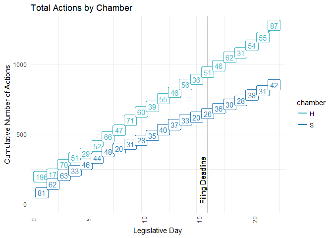

76 bills in the House and 38 bills have had floor votes. However, the majority of those votes have not been contested. A full 67% (51) of the floor votes on House bills and 68% (26) of Senate bills have been without opposition. While the GOP has a super-majority in both chambers, the fact that so many of the bills have been without opposition indicates that during this rather lazy first half of the session, the chamber has not dealt with many contentious issues.

However, many of the votes taken have been contested, and some of the members of the legislature in both parties are more likely to vote ‘NAY’. The graphs below show the voting record among *contested* votes – votes with at least one ‘Nay’ vote (in the House, n=25, in the Senate, n=12).

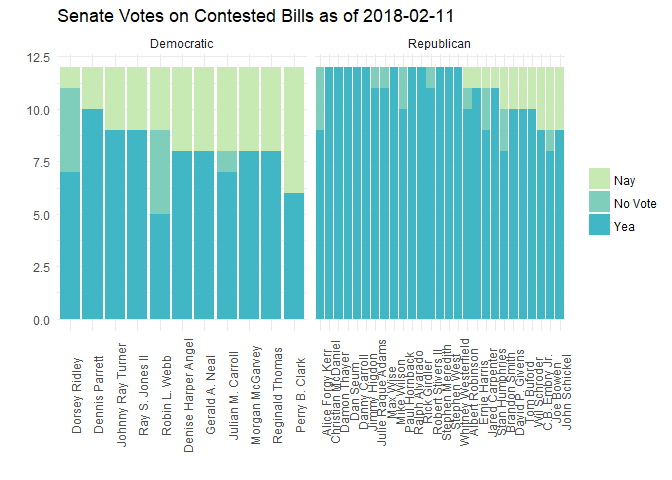

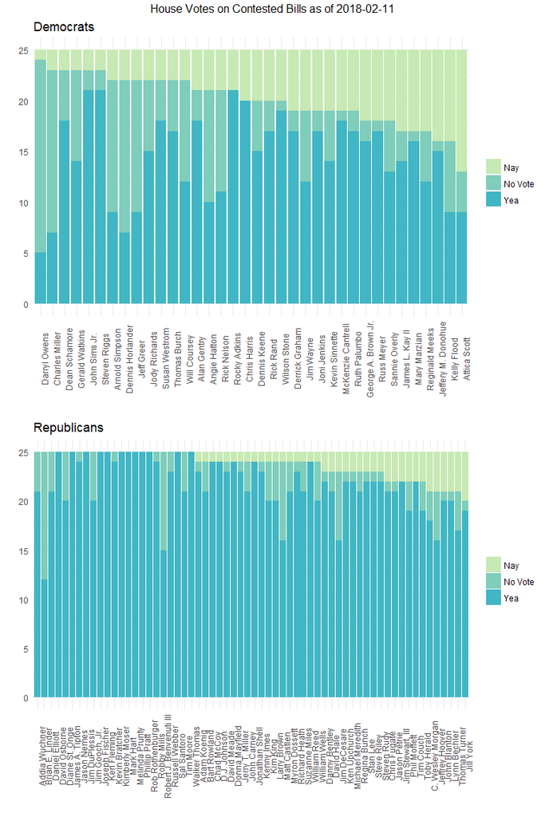

It should come as no surprise that the Democrats in the House who vote “Nay” the most often are Attica Scott and Kelly Flood. These woman are among the most progressive in the House, and reside in some of the safest Democratic seats in the legislature. Jeffrey Donohue in the House and Perry Clark in the Senate have also voted “Nay” at a very high clip – and both of these men represent districts who voted for Donald Trump in the Presidential election over Hillary Clinton. Please keep in mind that the number of “Nay” votes isn’t a very sophisticated way to look at ideological spread among a legislature. A more robust metric is `W-Nominate` or `DW-Nominate`, and I plan to do an analysis of votes using that metric once the session is over.

You may have noticed that some members of the Democratic caucus have a fairly large portion of “No Votes”. It’s been heavily reported that 11 members of the 36 member Democratic caucus are retiring from the legislature at the end of the year. The chart below shows the proportion of “No Votes” for the retiring Democrats (“No Vote” is separate from “Nay”, it indicates that the member was not present for the vote).

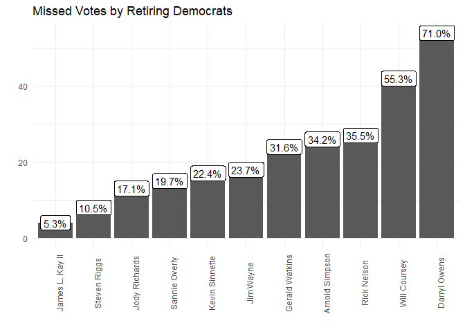

At this point in the session, a big chunk of the work is done in committees. Some of those committees have been busier than others. The charts below show the number of bills assigned to each committee in each chamber, and the status of those bills fills those bars.

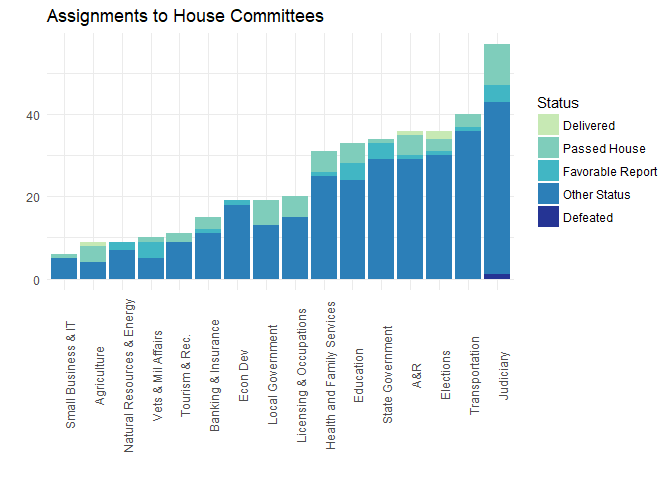

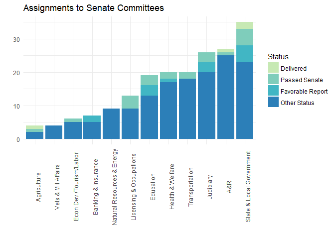

In the House, the Judiciary committee has had the most bills assigned to it, and has kept pace with the other committees, delivering a report on 26% of the bills it’s received (the average across committees is 24%). It terms of average production, the Agriculture Committee and the Veterans, Military Affairs, and Public Protection have delivered a report on more than half the bills they have received, and the Agriculture committee has even had more than half of the bills they’ve received pass out of the House altogether. The story of the single house bill which was defeated on the floor is an interesting one, and I wrote about it [here](https://rkahne.github.io/one_page/curious_hb77).

Impressively, the Senate has two committees (Veterans, Military Affairs, and Public Protection & Natural Resources and Energy) which have not yet delivered a report on a single bill. In the upper chamber, the State and Local Government Committee has been the most busy, delivering a report on 34% of bills, a percentage significantly higher than average (20%).

The legislature has a lot to do this year, and the time that they have to do it is quickly running out. The legislature is constitutionally obligated to deal with the budget, and every day without a pension bill makes the legislature look increasingly silly. The analysis above looks only at the data, and doesn’t take into account any of the political issues which are at play. For more information about those type of issues, I recommend listening to the podcast I do with Jazmin Smith, [My Old Kentucky Podcast](https://myoldkentuckypodcast.podbean.com/), and watching the [KET Legislative Update](https://www.ket.org/series/KGAOS/).

- Robert Kahne
- rkahne@gmail.com
- twitter: @rkahne